# Logistic Regression

## The Data

*The dataset is imported.*

```r
alc <- read.table("alc.txt", header = T, sep = ";")
```

There are **35** variables in the dataset with **382** observations in total. Among the variables there is some basic demographic data (e.g. sex, age, family size, etc.), some variables are related to school, some to personal life and relationships. G1, G2 and G3 are grades for the first period, second period and final grade accordingly.

The variables called *alc_use* shows the average weekly alcohol consumption while the variable *high_use* indicated average weekly alcohol consumption higher than 2.

```r
colnames(alc)
```

```
##  [1] "school"     "sex"        "age"        "address"    "famsize"
##  [6] "Pstatus"    "Medu"       "Fedu"       "Mjob"       "Fjob"
## [11] "reason"     "nursery"    "internet"   "guardian"   "traveltime"
## [16] "studytime"  "failures"   "schoolsup"  "famsup"     "paid"
## [21] "activities" "higher"     "romantic"   "famrel"     "freetime"
## [26] "goout"      "Dalc"       "Walc"       "health"     "absences"
## [31] "G1"         "G2"         "G3"         "alc_use"    "high_use"
```

```r
str(alc)
```

```
## 'data.frame':    382 obs. of  35 variables:
##  $ school    : Factor w/ 2 levels "GP","MS": 1 1 1 1 1 1 1 1 1 1 ...
##  $ sex       : Factor w/ 2 levels "F","M": 1 1 1 1 1 2 2 1 2 2 ...
##  $ age       : int  18 17 15 15 16 16 16 17 15 15 ...
##  $ address   : Factor w/ 2 levels "R","U": 2 2 2 2 2 2 2 2 2 2 ...
##  $ famsize   : Factor w/ 2 levels "GT3","LE3": 1 1 2 1 1 2 2 1 2 1 ...
##  $ Pstatus   : Factor w/ 2 levels "A","T": 1 2 2 2 2 2 2 1 1 2 ...
##  $ Medu      : int  4 1 1 4 3 4 2 4 3 3 ...
##  $ Fedu      : int  4 1 1 2 3 3 2 4 2 4 ...
##  $ Mjob      : Factor w/ 5 levels "at_home","health",..: 1 1 1 2 3 4 3 3 4 3 ...
##  $ Fjob      : Factor w/ 5 levels "at_home","health",..: 5 3 3 4 3 3 3 5 3 3 ...
##  $ reason    : Factor w/ 4 levels "course","home",..: 1 1 3 2 2 4 2 2 2 2 ...
##  $ nursery   : Factor w/ 2 levels "no","yes": 2 1 2 2 2 2 2 2 2 2 ...
##  $ internet  : Factor w/ 2 levels "no","yes": 1 2 2 2 1 2 2 1 2 2 ...
##  $ guardian  : Factor w/ 3 levels "father","mother",..: 2 1 2 2 1 2 2 2 2 2 ...
```

[output cut: 21 more lines]

I will analyse the relationships between alcohol consumption and 4 of the following variables:  
1. weekly study time (*studytime*)  
2. free time after school (*freetime*)  
3. quality of family relationships (*famrel*)  
4. age (*age*)

## Testing hypothesis

Four hypothesis related to the alcohol consumption and the chosen variables:  
**H1**: Students who study longer during the week, consume less alcohol compared to those who study less.  
**H2**: Those students who have more free time after school consume higher amounts of alcohol than those who have less free time.  
**H3**: Those who have better family relationships consume less alcohol than those in poor family relationships.  
**H4**: Younger students consume more alcohol than older students.

```r
library(ggplot2)
library(dplyr)
```

### First hypothesis

The relationship between alcohol consumption and weekly study time will be analysed.

In the survey students had to choose how many hours a week they study. The options were:  
1 - less than 2 hours  
2 - from 2 to 5 hours  
3 - from 5 to 10 hours  
4 - more than 10 hours

```r
summary(alc$studytime)
```

```
##    Min. 1st Qu.  Median    Mean 3rd Qu.    Max.
##   1.000   1.000   2.000   2.037   2.000   4.000
```

To visualize the data a boxplot will be drawn.

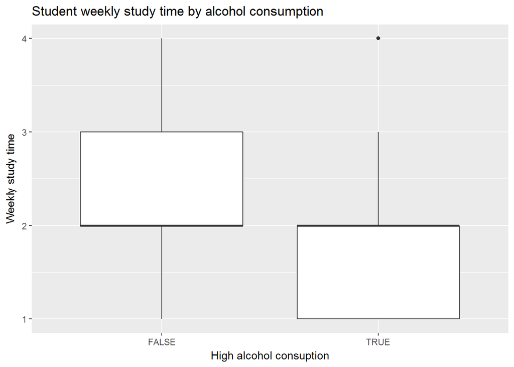

```r
g1 <- ggplot(alc, aes(x = high_use, y= studytime))
g1 + geom_boxplot(aes()) + xlab("High alcohol consuption") + ylab("Weekly study time") + ggtitle("Student weekly study time by alcohol consumption")
```

The table below shows the frequencies. It is clear that most of the students (195) study from 2 to 5 hours a week, while least students study more than 10 hours. Additionally, overall most students do not consume high amounts of alcohol weekly irrespectivelly of how much they study. However, it is obvious that students that study less than 2 hours a week have a higher proportion of students that consume more alcohol compared to all the other students.

```r
table_studytime <- xtabs(~high_use+studytime, data=alc)
ftable(table_studytime)
```

```
##          studytime   1   2   3   4
## high_use
## FALSE               58 135  52  23
## TRUE                42  60   8   4
```

Similar results are visible in the grapgh below.

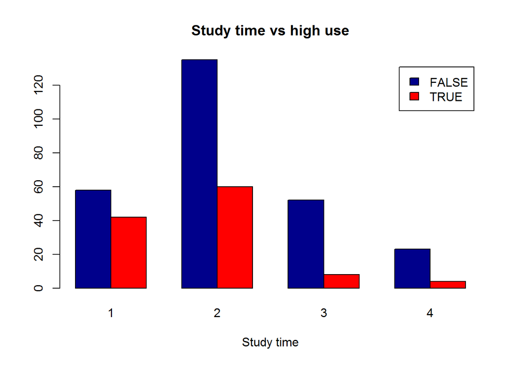

```r
counts_studytime <- table(alc$high_use, alc$studytime)
barplot(counts_studytime, main="Study time vs high use",
  xlab="Study time", col=c("darkblue","red"),
    legend = rownames(counts_studytime), beside=TRUE)
```

**H1**: Students who study longer during the week, consume less alcohol compared to those who study less.

**H1 is confimed.**

### Second Hypothesis

The relationship between alcohol consumption and amount of free time after school will be analysed.

In the survey students had to choose how much free time after school they have. The possible answers ranged from 1 - very low to 5 - very high.

We can see from the summary below that on average students chose answer 3, which is average amount of free time after school. However, all answers in the range were selected.

```r
summary(alc$freetime)
```

```
##    Min. 1st Qu.  Median    Mean 3rd Qu.    Max.
##    1.00    3.00    3.00    3.22    4.00    5.00
```

The box plot indicates that 50% of students who consume high amounts of alcohol and 50% of students who don’t had the same amount of free time (from average to high).

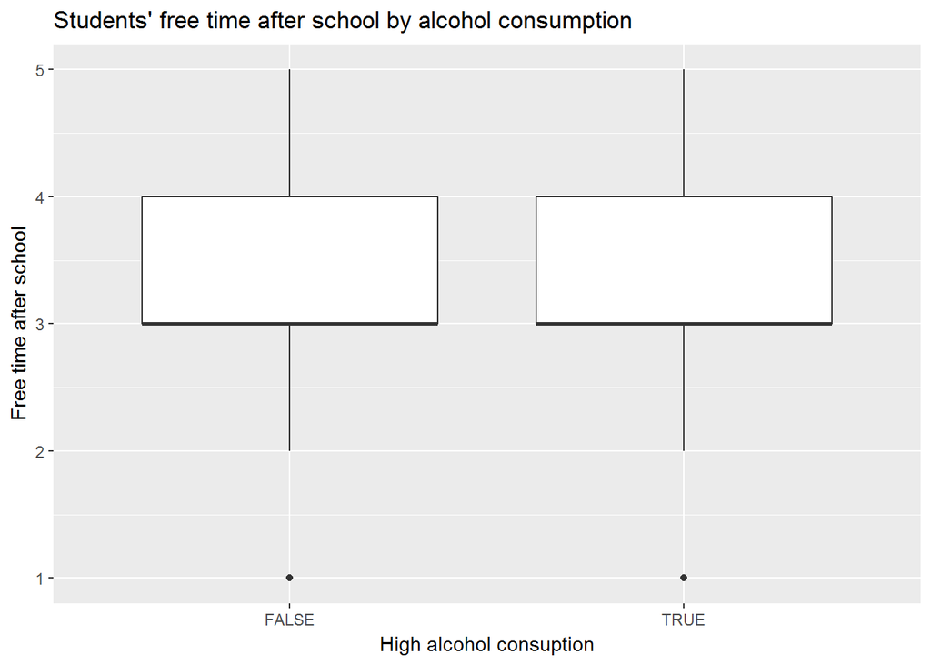

```r
g4 <- ggplot(alc, aes(x = high_use, y= freetime))
g4 + geom_boxplot(aes()) + xlab("High alcohol consuption") + ylab("Free time after school") + ggtitle("Students' free time after school by alcohol consumption")
```

**H2**: Those students who have more free time after school consume higher amounts of alcohol than those who have less free time.

### Third hypothesis

The relationship between alcohol consumption and quality of their family relationship will be analysed.

In the survey students had to choose wheather what is the quality of their family relationship. The possible answer options ranged from 1 - very bad to 5 - excellent.

On average students indicated that their relationship with the family are good (3.937), however, the whole range of answers was used in answering this question.

```r
summary(alc$famrel)
```

```
##    Min. 1st Qu.  Median    Mean 3rd Qu.    Max.
##   1.000   4.000   4.000   3.937   5.000   5.000
```

Frequencies table also shows that most of the students are in a good relationship with their family. Only 8 students indicated that the relationship was very poor.

```r
table_famrel <- xtabs(~high_use+famrel, data=alc)
ftable(table_famrel)
```

```
##          famrel   1   2   3   4   5
## high_use
## FALSE             6  10  39 135  78
## TRUE              2   9  25  54  24
```

The box plot shows that 50% of students who do not consume high amounts of alcohol have good or excellent relationships with their family, whereas, 50% of students who consume high amounts of alcohol have average or good relationships. Another interesting thing is that among the students who do not consume high amounts of alcohol the answers ranged from average to excellent, which outliers for 2 other options. In contast, the answers among the students who consume high amounts of alcohol, the answers ranged from poor to excellent, with an outlier in very poor. Thus, it can be stated that overall students who do not consume high amounts of alcohol are more in better relationships with their families.

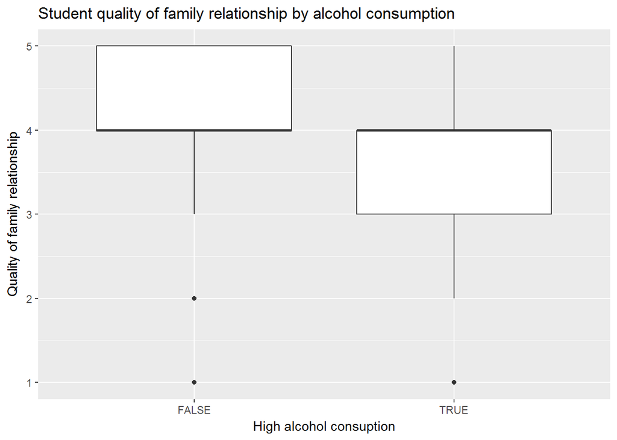

```r
g2 <- ggplot(alc, aes(x = high_use, y= famrel))
g2 + geom_boxplot(aes()) + xlab("High alcohol consuption") + ylab("Quality of family relationship") + ggtitle("Student quality of family relationship by alcohol consumption")
```

**H3**: Those who have better family relationships consume less alcohol than those in poor family relationships.

**H3 is confirmed.**

### Fourth hypothesis

The relationship between students’ alcohol consumption and their age will be analysed.

In the survey students had to indicate their actual age.

The students’ age ranged from 15 to 22 with average age of around 17.

```r
summary(alc$age)
```

```
##    Min. 1st Qu.  Median    Mean 3rd Qu.    Max.
##   15.00   16.00   17.00   16.59   17.00   22.00
```

The boxplot shows that 50% of students who do not consume high amounts of alcohol are between the age of 16 and 17, while 50% of students who consume higher amounts of alcohol are between the ages of 16 and 18 and their overall answer range is wider.

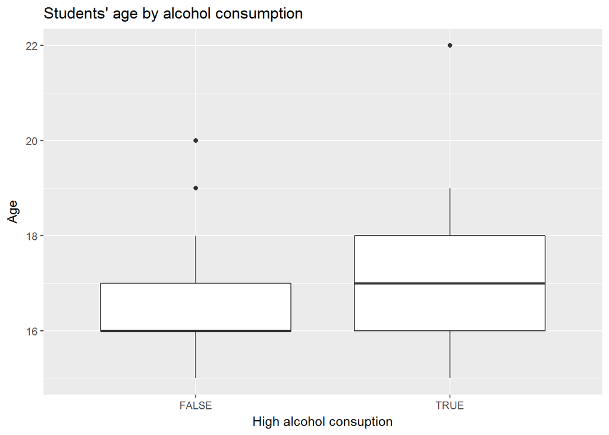

```r
g3 <- ggplot(alc, aes(x = high_use, y= age))
g3 + geom_boxplot(aes()) + xlab("High alcohol consuption") + ylab("Age") + ggtitle("Students' age by alcohol consumption")
```

**H4**: Younger students consume more alcohol than older students.

**H4 is declined.**

## Logistic regression model

A logistic regression will be used to statistically explore the four variables (*studytime, freetime, famrel, age*) and their relationship with the high/low alcohol consumption variable as the target variable.

```r
m <- glm(high_use ~ studytime + freetime + famrel + age, data = alc, family = "binomial")

summary(m)
```

```
##
## Call:
## glm(formula = high_use ~ studytime + freetime + famrel + age,
##     family = "binomial", data = alc)
##
## Deviance Residuals:
##     Min       1Q   Median       3Q      Max
## -1.7096  -0.8475  -0.6420   1.1883   2.1913
##
## Coefficients:
##             Estimate Std. Error z value Pr(>|z|)
## (Intercept)  -3.5585     1.7969  -1.980 0.047660 *
## studytime    -0.5548     0.1562  -3.551 0.000383 ***
## freetime      0.3498     0.1238   2.824 0.004736 **
## famrel       -0.3291     0.1299  -2.535 0.011253 *
## age           0.2356     0.1012   2.327 0.019949 *
## ---
## Signif. codes:  0 '***' 0.001 '**' 0.01 '*' 0.05 '.' 0.1 ' ' 1
##
## (Dispersion parameter for binomial family taken to be 1)
##
##     Null deviance: 465.68  on 381  degrees of freedom
## Residual deviance: 430.57  on 377  degrees of freedom
## AIC: 440.57
##
## Number of Fisher Scoring iterations: 4
```

```r
#chi sq
qchisq(0.95, 377)
```

```
## [1] 423.2743
```

The coeficients here mean that:  
If the value of studytime increases by one the model predicts that the log of the odds decreases by 0.55.  
If the value of freetime increases by one the model predicts that the log of the odds increases by 0.35.  
If the value of famrel increases by one the model predicts that the log of the odds decreases by 0.33.  
If the value of age increases by one the model predicts that the log of the odds increases by 0.24.

```r
coef(m)
```

```
## (Intercept)   studytime    freetime      famrel         age
##  -3.5585146  -0.5547942   0.3497904  -0.3291428   0.2355955
```

Odds ratios for freetime and age are higher than one thus it means they are positivelly associated with high use of alcohol.  
Whereas odd rations for studytime and famrel are lower than 1 so they can’t be positivelly associated with higher alcohol consumption.

```r
OR <- coef(m) %>% exp
CI <- confint(m) %>% exp
cbind(OR, CI)
```

```
##                    OR        2.5 %    97.5 %
## (Intercept) 0.0284811 0.0008002383 0.9372941
## studytime   0.5741904 0.4186785377 0.7735687
## freetime    1.4187702 1.1166313749 1.8164964
## famrel      0.7195403 0.5566658883 0.9276797
## age         1.2656622 1.0401492065 1.5488002
```

## Predictive Power of the Model

```r
probabilities <- predict(m, type = "response")
alc <- mutate(alc, probability = probabilities)
alc <- mutate(alc, prediction = probability > 0.5)
table(high_use = alc$high_use, prediction = alc$prediction)
```

```
##         prediction
## high_use FALSE TRUE
##    FALSE   249   19
##    TRUE     99   15
```

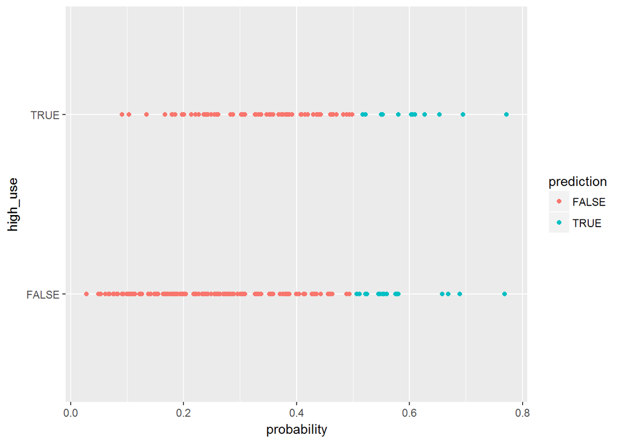

```r
gprob <- ggplot(alc, aes(x = probability, y = high_use, col = prediction))
gprob + geom_point()
```

```r
table(high_use = alc$high_use, prediction = alc$prediction) %>% prop.table() %>% addmargins()
```

```
##         prediction
## high_use      FALSE       TRUE        Sum
##    FALSE 0.65183246 0.04973822 0.70157068
##    TRUE  0.25916230 0.03926702 0.29842932
##    Sum   0.91099476 0.08900524 1.00000000
```

The average number of wrong predictions in the (training) data is 0.31.

```r
loss_func <- function(class, prob) {
  n_wrong <- abs(class - prob) > 0.5
  mean(n_wrong)
}
loss_func(class = alc$high_use, prob = alc$probability)
```

```
## [1] 0.3089005
```

```r
library(boot)
cv <- cv.glm(data = alc, cost = loss_func, glmfit = m, K = 10)
cv$delta[1]
```

```
## [1] 0.3141361
```